# Introduction

Este es un documento de ejemplo para ilustrar algunas de las características de **IPython Notebooks**. Un IPython notebook es otra herramienta de programación literaria, similar a R Markdown. Sin embargo, en este caso está diseñada para utilizarse con el lengauje de programación Python.

IPython es un intérprete de Python que ofrece muchas características avanzadas, poniéndo especial interés en facilitar la programación interactiva y la compartición rápida de información en programación científica. En esta línea, los *notebooks* proporcionan un método muy sencillo y eficiente para crear y organizar documentación de programación científica con Python que, además, permite editar y modificar los contenidos, así como evaluar los resultados de inmediato. Esto es posible gracias a que cada notebook cuenta con un intérprete de Python ejecutándose en segundo plano, que evalua las secciones de código insertadas y devuelve los resultados. La interfaz es accesible desde cualquier navegador web, trabajando en modo local (normalmente http://localhost:8888).

## Instalación

Para instalar IPython e IPython notebook solo hay que seguir [estas instrucciones](http://ipython.org/install.html). Si Python no está instalado por defecto en nuestro sistema operativo, la opción más recomendable es descargar e instalar directamente una distribución para programación científica en Python, como por ejemplo [Anaconda](http://continuum.io/downloads.html).

Por otro lado, se pueden consultar también numerosos ejemplos de *notebooks* creados por otros usuarios, y disponibles en el proyecto [nbviewer](http://nbviewer.ipython.org/). Por último, indicar que las partes de IPython independientes del lenguaje Python se han abstraído para crear el proyecto [Jupyter](http://jupyter.org/), que permite la creación de documentos de programación interactiva utilizando múltiples lenguajes.

# Primeros pasos

[Documentación](http://ipython.org/ipython-doc/3/notebook/index.html) para comenzar a utilizar IPython notebook.

La estructura del documento se divide en celdas (similares al concepto de *chunks* en R Markdown). Cada celda es independiente del resto y la podemos editar, modificar y ejecutar (si se trata de código) individualmente. También podemos modificar fácilmente su posición en el documento mediante los controles intuitivos que nos ofrece la interfaz web.

## Código y figuras

Obviamente, el objetivo más interesante es integrar código y texto en un mismo documento. La siguiente celda de código muestra un ejemplo de como conseguirlo. No hay más que crear una celda nueva (con el botón `Agregar celda` en el menú superior). Elegimos como tipo de contenido `Code` (si fuese texto como esta celda que estás leyendo, elegimos `Markdown` para utilizar la sintaxis de marcado que ya conocemos).

Ejemplo basado en http://www.scipy.org/Cookbook/Matplotlib/Show_colormaps y https://wakari.io/nb/url///wakari.io/static/notebooks/Lecture_4_Matplotlib.ipynb.

```python
# coding:utf-8
import numpy as np

vector = np.array([1,2,3,4])
matriz = np.array([[1, 2], [3, 4]])

print (type(vector), type(matriz))

print "Forma del objeto vector: %d" % vector.shape
print "Tamaño del objeto vector: %d" % vector.size
print "Forma del objeto matriz: %s" % str(matriz.shape)
print "Tamaño del objeto matriz: %d" % matriz.size
```

```
(<type 'numpy.ndarray'>, <type 'numpy.ndarray'>)
Forma del objeto vector: 4
Tamaño del objeto vector: 4
Forma del objeto matriz: (2, 2)
Tamaño del objeto matriz: 4
```

```python
# Mostrar imágenes generadas por matplotlib en el propio documento
# en lugar de en una nueva ventana
%pylab inline
```

```
array([  0.        ,   0.25645654,   0.51291309,   0.76936963,
         1.02582617,   1.28228272,   1.53873926,   1.7951958 ,
         2.05165235,   2.30810889,   2.56456543,   2.82102197,
         3.07747852,   3.33393506,   3.5903916 ,   3.84684815,
         4.10330469,   4.35976123,   4.61621778,   4.87267432,
         5.12913086,   5.38558741,   5.64204395,   5.89850049,
         6.15495704,   6.41141358,   6.66787012,   6.92432667,
         7.18078321,   7.43723975,   7.69369629,   7.95015284,
         8.20660938,   8.46306592,   8.71952247,   8.97597901,
         9.23243555,   9.4888921 ,   9.74534864,  10.00180518,
        10.25826173,  10.51471827,  10.77117481,  11.02763136,
        11.2840879 ,  11.54054444,  11.79700098,  12.05345753,
        12.30991407,  12.56637061])
```

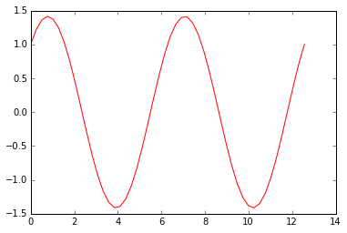

```python
x = linspace(0, 4*pi)
y = sin(x) + cos(x)
plot(x, y, 'r')
x
```

```
[ 0.48142809  0.4648895   2.49548597 -0.18398977 -0.31594721  0.43080065
  0.82299948  1.26934379 -0.47724752 -1.33546371]
```

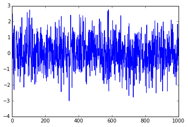

```python
yrand = randn(1000)
print yrand[0:10]
plot(yrand)
```

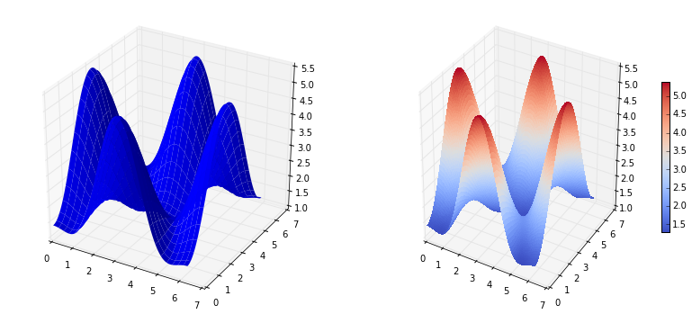

```python
import matplotlib.pyplot as plt
from mpl_toolkits.mplot3d.axes3d import Axes3D


def flux_qubit_potential(phi_m, phi_p):
    return 2 + alpha - 2 * cos(phi_p)*cos(phi_m) - alpha * cos(phi_ext - 2*phi_p)

alpha = 0.7
phi_ext = 2 * pi * 0.5
phi_m = linspace(0, 2*pi, 100)
phi_p = linspace(0, 2*pi, 100)
X,Y = meshgrid(phi_p, phi_m)
Z = flux_qubit_potential(X, Y).T

fig = plt.figure(figsize=(14,6))

# El argumento projection='3d' en add_subplot hace que el objeto reconozca un entorno 3D
ax = fig.add_subplot(1, 2, 1, projection='3d')

p = ax.plot_surface(X, Y, Z, rstride=4, cstride=4, linewidth=0)

# surface_plot con gradiente y barra en color
ax = fig.add_subplot(1, 2, 2, projection='3d')
p = ax.plot_surface(X, Y, Z, rstride=1, cstride=1, cmap=cm.coolwarm, linewidth=0, antialiased=False)
cb = fig.colorbar(p, shrink=0.5)
```

## Tablas y fórmulas

También es posible insertar tablas y fórmulas. Los principios son similares a R Markdown, ya que también se utiliza MathJax para renderizar las fórmulas en el documento HTML.

Al igual que en en el caso de R Markdown, se pueden incluir en línea ($y = f(x) = x^2$ para $x > 0$) o por separado:

$$Pr(Y \in A)=\sum_{y \in A} p(y)$$ $$Pr(Y \in A)=\int_{y \in A} p(y)dy$$

## Imágenes

Ejemplo de inserción de una imagen:

[figure not shown]